# PCA

Sean Schilk

9/19/2025

## Question 1

We first read in the data set and load the `tidyverse` and `GGally` packages.

```r
setwd("~/STA419/REDO/1.Basics") # this will be different for you

library(tidyverse)
library(GGally)

pollution <- read_csv("HW1data.csv")
  glimpse(pollution)
```

```
## Rows: 41
## Columns: 8
## $ Region  <chr> "NE", "MW", "S", "W", "MW", "W", "W", "MW", "S", "W", "MW", "S…
## $ SO2     <dbl> 46, 11, 24, 47, 11, 31, 110, 23, 65, 26, 9, 17, 17, 35, 56, 10…
## $ temp    <dbl> 47.6, 56.8, 61.5, 55.0, 47.1, 55.2, 50.6, 54.0, 49.7, 51.5, 66…
## $ manu    <dbl> 44, 46, 368, 625, 391, 35, 3344, 462, 1007, 266, 641, 454, 104…
## $ popul   <dbl> 116, 244, 497, 905, 463, 71, 3369, 453, 751, 540, 844, 515, 20…
## $ wind    <dbl> 8.8, 8.9, 9.1, 9.6, 12.4, 6.5, 10.4, 7.1, 10.9, 8.6, 10.9, 9.0…
## $ precip  <dbl> 33.36, 7.77, 48.34, 41.31, 36.11, 40.75, 34.44, 39.04, 34.99, …
## $ predays <dbl> 135, 58, 115, 111, 166, 148, 122, 132, 155, 134, 78, 86, 103, …
```

#### (a) Create a new data set (but don’t overwrite the original!) that only includes the quantitative variables: SO2, temp, manu, popul, precip, wind, and predays. In other words, remove the Region variable for now. Hint: Consider the select( ) function from the tidyverse package. You should now have seven variables

####- (b) Use the ggpairs( ) function to look at the pairwise relationships between these 7 variables. Which two pairs have the largest positive correlation? Which two pairs have the largest negative correlation?

```r
pollution.quant <- select(pollution, SO2:predays)
  glimpse(pollution.quant)
```

```
## Rows: 41
## Columns: 7
## $ SO2     <dbl> 46, 11, 24, 47, 11, 31, 110, 23, 65, 26, 9, 17, 17, 35, 56, 10…
## $ temp    <dbl> 47.6, 56.8, 61.5, 55.0, 47.1, 55.2, 50.6, 54.0, 49.7, 51.5, 66…
## $ manu    <dbl> 44, 46, 368, 625, 391, 35, 3344, 462, 1007, 266, 641, 454, 104…
## $ popul   <dbl> 116, 244, 497, 905, 463, 71, 3369, 453, 751, 540, 844, 515, 20…
## $ wind    <dbl> 8.8, 8.9, 9.1, 9.6, 12.4, 6.5, 10.4, 7.1, 10.9, 8.6, 10.9, 9.0…
## $ precip  <dbl> 33.36, 7.77, 48.34, 41.31, 36.11, 40.75, 34.44, 39.04, 34.99, …
## $ predays <dbl> 135, 58, 115, 111, 166, 148, 122, 132, 155, 134, 78, 86, 103, …
```

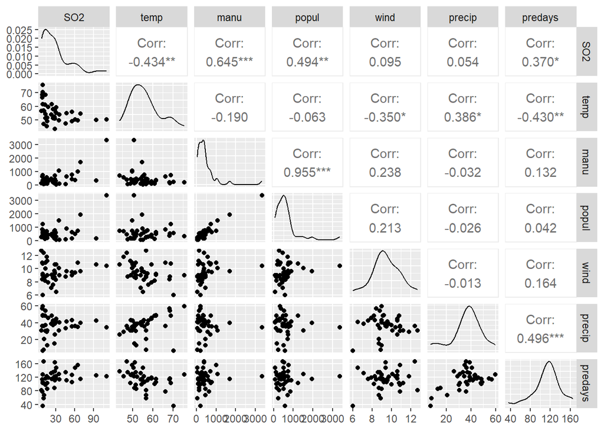

```r
ggpairs(pollution.quant)
```

We can also see that the number of days with precipitation has a moderate positive correlation with the amount of precicipation ($r = 0.496$), the amount of precipication has a moderate positive correlation with the temperature ($r = 0.386$). Wind and temperature, along with number of precipitation days and temperature have moderate negative correlations ($r = -0.350$ and $r = -0.430$, respectively).

#### (c) Run PCA (without scaling) on these 7 variables. What proportion of the variation does the first PC explain? What about the first two?

```r
pca <- prcomp(pollution.quant)
  summary(pca)
```

```
## Importance of components:
##                             PC1       PC2      PC3      PC4      PC5     PC6
## Standard deviation     799.0444 121.70472 26.49453 14.31789 10.80299 3.47233
## Proportion of Variance   0.9758   0.02264  0.00107  0.00031  0.00018 0.00002
## Cumulative Proportion    0.9758   0.99841  0.99949  0.99980  0.99998 1.00000
##                          PC7
## Standard deviation     1.204
## Proportion of Variance 0.000
## Cumulative Proportion  1.000
```

The first PC explains 97.58% of the original variation. The first two PCs explain about 99.8% of the original variation.

#### (d) Which variables had the largest (in absolute value) loading values in PC1? Explain why this is the case. Hint: look at the variances of the 7 variables

```r
pca$rotation
```

```
##                   PC1          PC2          PC3         PC4          PC5
## SO2     -0.0168607518  0.099835625  0.208775573 -0.95883106  0.152191203
## temp     0.0011417794 -0.025814390 -0.071600745  0.11014784  0.477854201
## manu    -0.6968327936  0.710249079 -0.067182201  0.07319788  0.009643654
## popul   -0.7170284512 -0.692912523  0.056666935 -0.04906669 -0.010735457
## wind    -0.0004067530  0.001011680  0.005386606  0.01506609 -0.025401917
## precip   0.0004336922 -0.001225937  0.265807619  0.16261712  0.832729325
## predays -0.0028836950  0.069155051  0.934279828  0.18459052 -0.232812295
##                  PC6           PC7
## SO2     -0.053952911 -2.704138e-02
## temp    -0.852534945 -1.640507e-01
## manu    -0.002153023  1.136208e-03
## popul    0.002915751 -5.682006e-05
## wind     0.176541256 -9.838347e-01
## precip   0.453206155  6.376788e-02
## predays -0.183568735 -1.891454e-02
```

```r
round(apply(pollution.quant, 2, var), 2) # rounded variances (to two decimal places) of variance for each variable
```

```
##       SO2      temp      manu     popul      wind    precip   predays
##    550.95     52.24 317502.89 335371.89      2.04    138.57    702.59
```

manu (-0.697) and popul (-0.717) had the two largest (in absolute value) loading coefficients in PC1. These coefficients are MUCH larger than the rest. The reason is because these two variables have variances that are orders of magnitude higher than the other variables.

#### (e) Verify that the sum of the variances of the projected values is equal to the sum of the variances of the original variables (i.e. we have preserved all the variation in the original data set

```r
sum(apply(pollution.quant, 2, var)) # sum of variance of all variables
```

```
## [1] 654321.2
```

```r
sum(pca$sdev^2) # sum of the squared eigenvalues from PCA for each PC
```

```
## [1] 654321.2
```

```r
sum(diag(var(pca$x))) # sum of variances of rotated observations
```

```
## [1] 654321.2
```

We verify they are the same. In other words, we just showed that the final PCs explained all of the original variation in the data set

#### (f) Now run PCA after scaling the variables. What proportion of the variation is explained by the first and first two PCs.

```r
pca.sc <- prcomp(pollution.quant, scale = TRUE)
  summary(pca.sc)
```

```
## Importance of components:
##                           PC1    PC2    PC3    PC4     PC5     PC6     PC7
## Standard deviation     1.6517 1.2298 1.1811 0.9445 0.58888 0.31668 0.15973
## Proportion of Variance 0.3897 0.2160 0.1993 0.1274 0.04954 0.01433 0.00364
## Cumulative Proportion  0.3897 0.6058 0.8051 0.9325 0.98203 0.99636 1.00000
```

#### (g) Which variables got positive loading values for PC1? Which got negative values? What about for PC2?

## (h) Which variables got the largest (in absolute value) loading values in PC1 and PC2?

```r
pca.sc$rotation
```

```
##                   PC1         PC2        PC3         PC4        PC5         PC6
## SO2     -0.4896988171 -0.08457563 -0.0143502  0.40421007 -0.7303942 -0.18334573
## temp     0.3153706901  0.08863789 -0.6771362 -0.18522794 -0.1624652 -0.61066107
## manu    -0.5411687028  0.22588109 -0.2671591 -0.02627237  0.1641011  0.04273352
## popul   -0.4875881115  0.28200380 -0.3448380 -0.11340377  0.3491048  0.08786327
## wind    -0.2498749284 -0.05547149  0.3112655 -0.86190131 -0.2682549 -0.15005378
## precip  -0.0001873122 -0.62587937 -0.4920363 -0.18393719 -0.1605988  0.55357384
## predays -0.2601790729 -0.67796741  0.1095789  0.10976070  0.4399698 -0.50494668
##                  PC7
## SO2     -0.149529278
## temp     0.023664113
## manu     0.745180920
## popul   -0.649125507
## wind    -0.015765377
## precip   0.010315309
## predays -0.008217393
```

For PC1, `temp` had a positive loading coefficient and the rest were negative. For PC2, `temp`, `manu`, and `popul` were positive and the rest were negative.

In terms of actual values, in PC1, `SO2`, `manu`, and `popul` had the largest absolute values. Those arrows go furthest to the left. For PC2, `precip` and `predays` have the largest negative values so they go the furthest down. `manu` and `popul` have the largest postiive values. So those arrows go the highest up.

##(i) Look at the biplot of the first two PCs. Verify that the arrows and relative lengths are reasonable based on what you said in the last two parts.

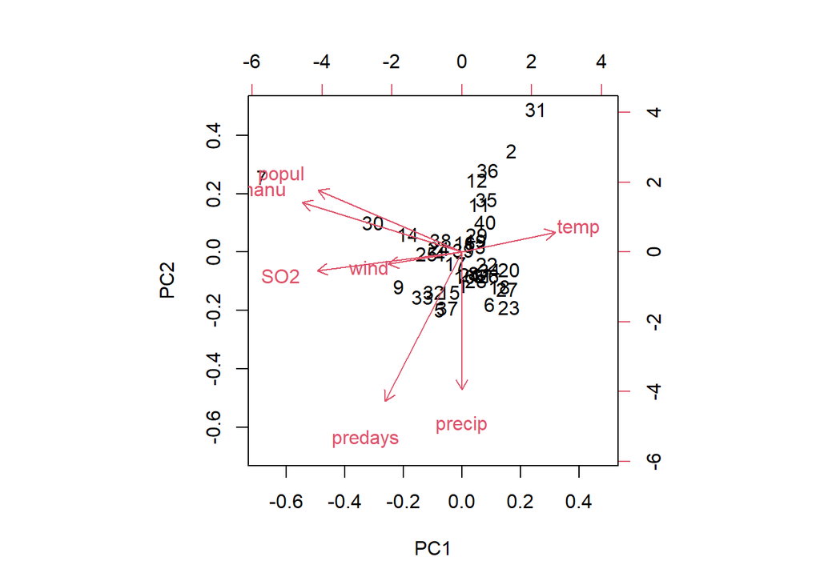

```r
biplot(pca.sc)
```

This is verified in the biplot since `temp` goes to the right and the rest go to the left. Also, `temp`, `popul`, and `manu` go up and the rest go down.

#### (j) Now, let’s compare two observations that are near each other in one dimension, but far away in the other dimension. Type: pollution[c(31, 23), ]. Based on the values for these two observations, explain why they are both to the “right” on the plot, but observation 31 is near the “top” and 23 is closer to the “bottom.

```r
pollution[c(31, 23), ]
```

| Region | SO2 | temp | manu | popul | wind | precip | predays |
| --- | --- | --- | --- | --- | --- | --- | --- |
| MW | 10 | 70.3 | 213 | 582 | 6 | 7.05 | 36 |
| MW | 10 | 75.5 | 207 | 335 | 9 | 59.80 | 128 |

```r
round(apply(pollution.quant, 2, mean)) # get rounded means of each variable
```

```
##     SO2    temp    manu   popul    wind  precip predays
##      30      56     463     609       9      37     114
```

These two observations are to the right in the biplot. So their temperatures tend to be higher than average, but their populations, manufacturing jobs, and pollution levels tend be lower than average.

#### (k) Repeat the previous step but use observations 30 and 9. Why are these to the “left” of the previous two observations and why is observation 30 “above” observations 9?

```r
pollution[c(30, 9), ]
```

| Region | SO2 | temp | manu | popul | wind | precip | predays |
| --- | --- | --- | --- | --- | --- | --- | --- |
| NE | 69 | 54.6 | 1692 | 1950 | 9.6 | 39.93 | 115 |
| S | 65 | 49.7 | 1007 | 751 | 10.9 | 34.99 | 155 |

Observations 30 and 9 are to the left in the biplot. So their temperature values are lower than average, but manufacturing, population, and pollution levels are higher than average.

Observation 30 is above 9. We can see that observation 30 has much higher manufacturing and population values than observation 9, but lower `predays` (`precip` is higher, but they are pretty similar).

#### (l) Verify that the pairwise correlations between the PCs are all functionally 0.

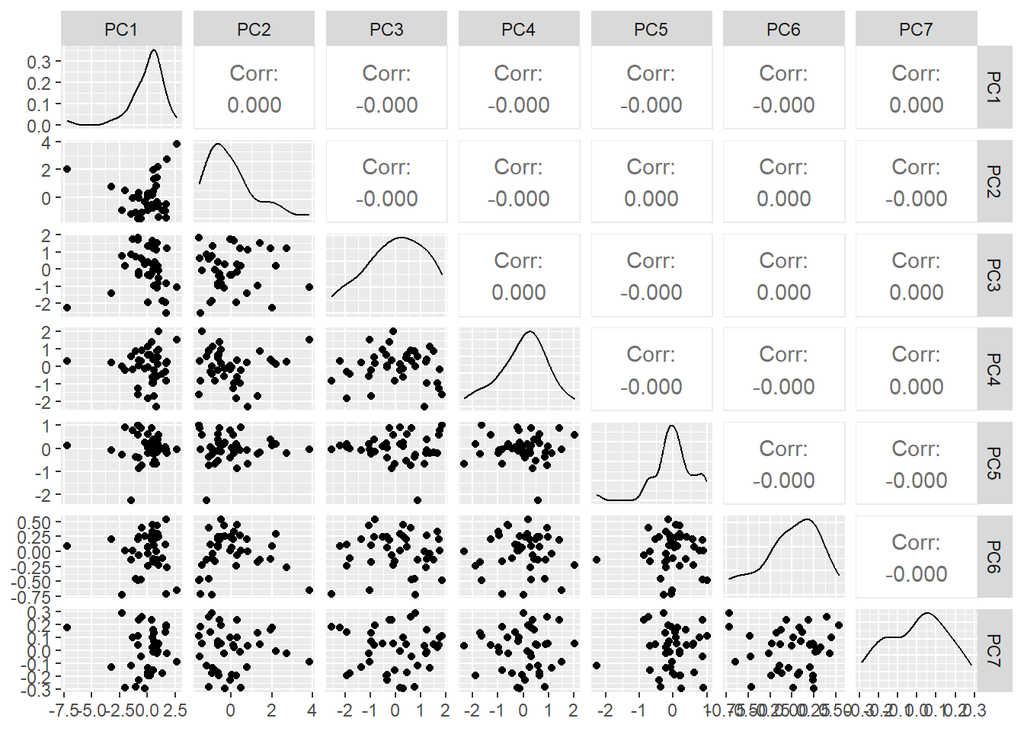

```r
ggpairs(pca.sc$x)
```

Here, we show that the correlations between all the projected observations are 0. PCA forces this to be true. Recall that many of the original variables were very strongly correlated (see part (b))

#### (m) Look at the scree plot of the PCs. How many PCs do you think is appropriate here? You must explain your reasoning to receive full credit!

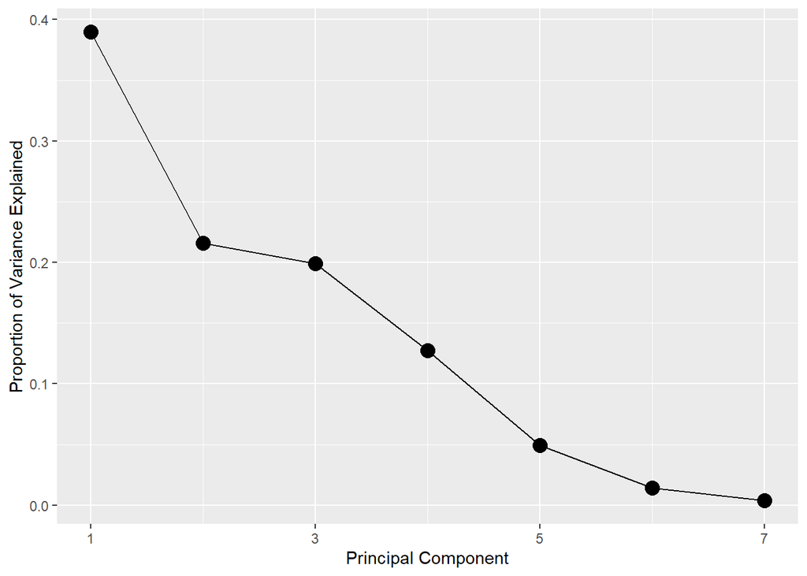

```r
scree <- data.frame(PC = 1:7, Prop.Var = pca.sc$sdev^2/sum(pca.sc$sdev^2))

# Scree plot
ggplot(scree, aes(x = PC, y = Prop.Var)) +
  geom_line() +
  geom_point(size=4)+
  scale_x_continuous(breaks=seq(1, 9, 2)) +
  xlab("Principal Component") +
  ylab("Proportion of Variance Explained")
```

Let’s plot the proportion of the variation explained for each of the PCs. We call this plot an elbow or scree plot. Ideally, we want to see an *elbow* someplace where we start to get *diminishing returns*. From this scree plot, we can see a subtle elbow at $k = 2$ and $k = 5$ or 6. Let’s choose $k = 2$ for simplicity (this is often the case when it’s not obvious).

#### (n) Project the observations onto the first two PCs. Color these projected values by their respective regions. Hint: Here, you will combine the projected values with the Region variable that you original left out. You can create a new data set using the data.frame( ) funciton.

Similar looking plot to biplot. But now we remove the arrows and color the points by their respective regions.

```r
new.coords <- pca.sc$x[ , 1:2] # projected observations onto first two PCs

regions <- pollution$Region

new.coords.reg <- data.frame(new.coords, regions) # create new data frame that adds a column to projected observations with original region value
  str(new.coords.reg)
```

```
## 'data.frame':    41 obs. of  3 variables:
##  $ PC1    : num  0.0339 1.7945 0.611 -0.7909 -0.8172 ...
##  $ PC2    : num  -0.8988 2.7294 -0.6303 -0.0345 -1.5497 ...
##  $ regions: chr  "NE" "MW" "S" "W" ...
```

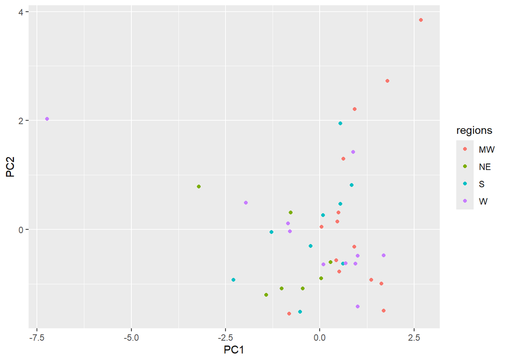

```r
ggplot(new.coords.reg, aes(x = PC1, y = PC2, color = regions)) +
  geom_point()
```